# Practical Machine Learning Project

Tanmay Bhatt

6/2/2022

## Introduction

One thing that people regularly do is quantify how much of a particular activity they do, but they rarely quantify how well they do it. In this project, data from *accelerometers on the belt, forearm, arm, and dumbbell* of 6 participants are used to *predict the manner* in which they perform unilateral dumbbell biceps curls. The 5 possible methods are:

A: exactly according to the specification B: throwing the elbows to the front C: lifting the dumbbell only halfway D: lowering the dumbbell only halfway E: throwing the hips to the front

## Setup, load packages and data

The library packages required and datasets were first loaded as below:

```r
knitr::opts_chunk$set(warning=F)
set.seed(77)
library(corrplot)
library(rattle)
library(randomForest)
library(caret)
library(rpart.plot)
train_val <- read.csv("pml-training.csv")
test <- read.csv("pml-testing.csv")
```

### Examine Data

The data structure were then examined:

```r
names(train_val)
names(test)
# str(train_val)
# str(test)
```

### Handle Missing Data

It was found that the variables have either none missing entries or are mostly unfilled.

```r
apply(X=train_val, MARGIN=2, FUN=function(x) {sum(is.na(x))})
```

```
##                        X                user_name     raw_timestamp_part_1
##                        0                        0                        0
##     raw_timestamp_part_2           cvtd_timestamp               new_window
##                        0                        0                        0
##               num_window                roll_belt               pitch_belt
##                        0                        0                        0
##                 yaw_belt         total_accel_belt       kurtosis_roll_belt
##                        0                        0                        0
##      kurtosis_picth_belt        kurtosis_yaw_belt       skewness_roll_belt
##                        0                        0                        0
##     skewness_roll_belt.1        skewness_yaw_belt            max_roll_belt
##                        0                        0                    19216
##           max_picth_belt             max_yaw_belt            min_roll_belt
##                    19216                        0                    19216
##           min_pitch_belt             min_yaw_belt      amplitude_roll_belt
##                    19216                        0                    19216
##     amplitude_pitch_belt       amplitude_yaw_belt     var_total_accel_belt
##                    19216                        0                    19216
##            avg_roll_belt         stddev_roll_belt            var_roll_belt
##                    19216                    19216                    19216
##           avg_pitch_belt        stddev_pitch_belt           var_pitch_belt
##                    19216                    19216                    19216
##             avg_yaw_belt          stddev_yaw_belt             var_yaw_belt
##                    19216                    19216                    19216
##             gyros_belt_x             gyros_belt_y             gyros_belt_z
##                        0                        0                        0
##             accel_belt_x             accel_belt_y             accel_belt_z
##                        0                        0                        0
##            magnet_belt_x            magnet_belt_y            magnet_belt_z
##                        0                        0                        0
##                 roll_arm                pitch_arm                  yaw_arm
##                        0                        0                        0
##          total_accel_arm            var_accel_arm             avg_roll_arm
##                        0                    19216                    19216
##          stddev_roll_arm             var_roll_arm            avg_pitch_arm
##                    19216                    19216                    19216
##         stddev_pitch_arm            var_pitch_arm              avg_yaw_arm
##                    19216                    19216                    19216
##           stddev_yaw_arm              var_yaw_arm              gyros_arm_x
##                    19216                    19216                        0
```

[output cut: 53 more lines]

```
##                        0                        0                    19216
##         avg_roll_forearm      stddev_roll_forearm         var_roll_forearm
##                    19216                    19216                    19216
##        avg_pitch_forearm     stddev_pitch_forearm        var_pitch_forearm
##                    19216                    19216                    19216
##          avg_yaw_forearm       stddev_yaw_forearm          var_yaw_forearm
##                    19216                    19216                    19216
##          gyros_forearm_x          gyros_forearm_y          gyros_forearm_z
##                        0                        0                        0
##          accel_forearm_x          accel_forearm_y          accel_forearm_z
##                        0                        0                        0
##         magnet_forearm_x         magnet_forearm_y         magnet_forearm_z
##                        0                        0                        0
##                   classe
##                        0
```

The variables with mostly missing values in the test set were first dropped:

```r
train_val <- train_val[, colSums(is.na(test)) == 0]
test <- test[, colSums(is.na(test)) == 0]
```

### Preprocess Data

The cleaning was followed by variables that have very few unique values relative to the number of sample:

```r
nzv_vars <- nearZeroVar(train_val)
train_val <- train_val[, -nzv_vars]
test <- test[, -nzv_vars]
```

And also variables that only serve for identification purposes:

```r
train_val <- train_val[, -(1:5)]
test <- test[, -(1:5)]
```

The data type of the variable to be predicted was converted into a categorical variable:

```r
class(train_val$classe)
```

```
## [1] "character"
```

```r
train_val$classe <- factor(train_val$classe)
```

### Create Training and Validation Datasets

The cleaned train dataset was split into datasets for training (70%) and validation (30%).

```r
train_id <- createDataPartition(y=train_val$classe, p=0.70, list=F)
train <- train_val[train_id, ]
validation <- train_val[-train_id, ]
```

### Correlation Analysis

The correlations between all variables except response variable in the train set were then visualized:

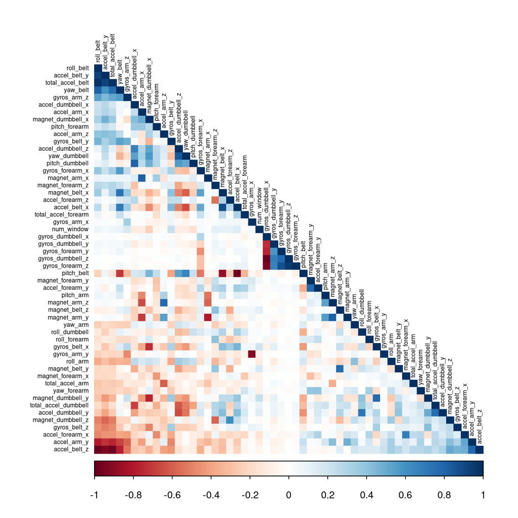

```r
corr_mat <- cor(train[, -ncol(train)])
corrplot(corr=corr_mat, method="color", type="lower", order="FPC", tl.cex=0.5, tl.col=rgb(0, 0, 0))
```

And the variables with correlations higher than 0.8 were listed as below:

```r
findCorrelation(x=corr_mat, cutoff=0.8, names=T)
```

```
##  [1] "accel_belt_z"     "roll_belt"        "accel_belt_y"     "accel_dumbbell_z"
##  [5] "accel_belt_x"     "pitch_belt"       "accel_arm_x"      "accel_dumbbell_x"
##  [9] "magnet_arm_y"     "gyros_forearm_y"  "gyros_dumbbell_x" "gyros_dumbbell_z"
## [13] "gyros_arm_x"
```

## Models Training

A **Random Forest** and a **Generalized Boosted Model** were chosen for the activity recognition prediction due to their robustness to correlated covariates and outliers. Besides, the feature selection could also be taken care of automatically. The model that achieves better accuracy using **5-fold cross validation** will be used to predict the test set `classe`. The results were visualized using a confusion matrix.

### Random Forest

The random forest model was trained as below:

```r
controlRF <- trainControl(method="cv", number=5)
modelRF <- train(classe~., data=train, method="rf", trControl=controlRF)
modelRF$finalModel
```

```
##
## Call:
##  randomForest(x = x, y = y, mtry = min(param$mtry, ncol(x)))
##                Type of random forest: classification
##                      Number of trees: 500
## No. of variables tried at each split: 27
##
##         OOB estimate of  error rate: 0.27%
## Confusion matrix:
##      A    B    C    D    E  class.error
## A 3904    1    0    0    1 0.0005120328
## B    8 2648    2    0    0 0.0037622272
## C    0    6 2386    4    0 0.0041736227
## D    0    0    7 2244    1 0.0035523979
## E    0    1    0    6 2518 0.0027722772
```

The model was then evaluated using the validation dataset:

```r
predictRF <- predict(object=modelRF, newdata=validation)
confmatRF <- confusionMatrix(predictRF, validation$classe)
confmatRF
```

```
## Confusion Matrix and Statistics
##
##           Reference
## Prediction    A    B    C    D    E
##          A 1674    3    0    0    0
##          B    0 1133    0    0    0
##          C    0    2 1026    3    0
##          D    0    1    0  961    1
##          E    0    0    0    0 1081
##
## Overall Statistics
##
##                Accuracy : 0.9983
##                  95% CI : (0.9969, 0.9992)
##     No Information Rate : 0.2845
##     P-Value [Acc > NIR] : < 2.2e-16
##
##                   Kappa : 0.9979
##
##  Mcnemar's Test P-Value : NA
##
## Statistics by Class:
##
##                      Class: A Class: B Class: C Class: D Class: E
## Sensitivity            1.0000   0.9947   1.0000   0.9969   0.9991
## Specificity            0.9993   1.0000   0.9990   0.9996   1.0000
## Pos Pred Value         0.9982   1.0000   0.9952   0.9979   1.0000
## Neg Pred Value         1.0000   0.9987   1.0000   0.9994   0.9998
## Prevalence             0.2845   0.1935   0.1743   0.1638   0.1839
## Detection Rate         0.2845   0.1925   0.1743   0.1633   0.1837
## Detection Prevalence   0.2850   0.1925   0.1752   0.1636   0.1837
## Balanced Accuracy      0.9996   0.9974   0.9995   0.9982   0.9995
```

The estimated out-of-sample error was:

```r
round(1 - as.numeric(confmatRF$overall['Accuracy']), 4)
```

```
## [1] 0.0017
```

The confusion matrix was visualized below:

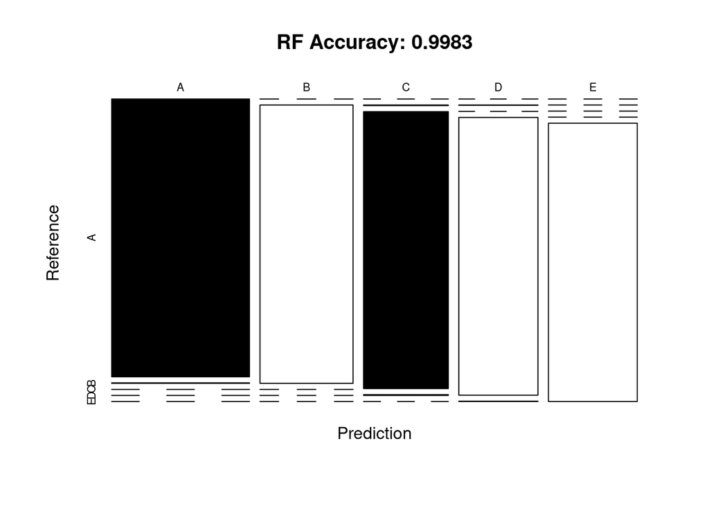

```r
plot(confmatRF$table, col=confmatRF$byClass, main=paste("RF Accuracy:", round(confmatRF$overall['Accuracy'], 4)))
```

### Generalized Boosted Model

The GBM model was trained as below:

```r
controlGBM <- trainControl(method="cv", number=5)
modelGBM <- train(classe~., data=train, method="gbm", trControl=controlGBM, verbose=F)
modelGBM$finalModel
```

```
## A gradient boosted model with multinomial loss function.
## 150 iterations were performed.
## There were 53 predictors of which 53 had non-zero influence.
```

And similarly evaluated using the validation dataset:

```r
predictGBM <- predict(object=modelGBM, newdata=validation)
confmatGBM <- confusionMatrix(predictGBM, validation$classe)
confmatGBM
```

```
## Confusion Matrix and Statistics
##
##           Reference
## Prediction    A    B    C    D    E
##          A 1670   11    0    1    0
##          B    3 1117    6    5    4
##          C    0   10 1017    7    2
##          D    1    1    3  948    6
##          E    0    0    0    3 1070
##
## Overall Statistics
##
##                Accuracy : 0.9893
##                  95% CI : (0.9863, 0.9918)
##     No Information Rate : 0.2845
##     P-Value [Acc > NIR] : < 2.2e-16
##
##                   Kappa : 0.9865
##
##  Mcnemar's Test P-Value : NA
##
## Statistics by Class:
##
##                      Class: A Class: B Class: C Class: D Class: E
## Sensitivity            0.9976   0.9807   0.9912   0.9834   0.9889
## Specificity            0.9972   0.9962   0.9961   0.9978   0.9994
## Pos Pred Value         0.9929   0.9841   0.9817   0.9885   0.9972
## Neg Pred Value         0.9990   0.9954   0.9981   0.9968   0.9975
## Prevalence             0.2845   0.1935   0.1743   0.1638   0.1839
## Detection Rate         0.2838   0.1898   0.1728   0.1611   0.1818
## Detection Prevalence   0.2858   0.1929   0.1760   0.1630   0.1823
## Balanced Accuracy      0.9974   0.9884   0.9937   0.9906   0.9941
```

The estimated out-of-sample error was:

```r
round(1 - as.numeric(confmatGBM$overall['Accuracy']), 4)
```

```
## [1] 0.0107
```

The confusion matrix was visualized below:

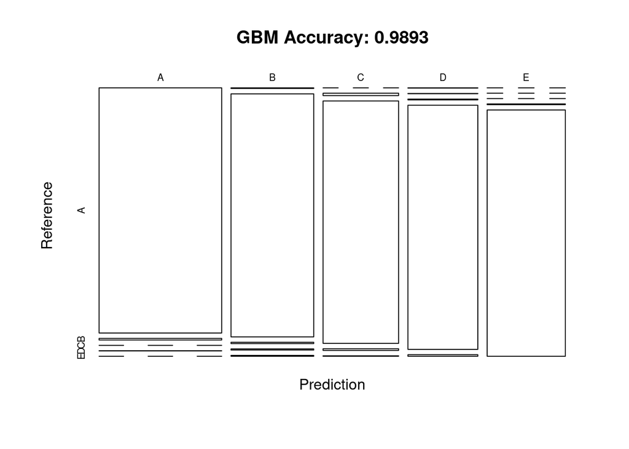

```r
plot(confmatGBM$table, col=confmatGBM$byClass, main=paste("GBM Accuracy:", round(confmatGBM$overall['Accuracy'], 4)))
```

## Test Set Prediction

Since the Random Forest model yields higher accuracy, it was used to predict the `classe` of the test set:

```r
predict(object=modelRF, newdata=test)
```

```
##  [1] B A B A A E D B A A B C B A E E A B B B
## Levels: A B C D E
```